# Analysis of NYPD Stop-and-Frisk Data (2024)

Data Science Portfolio Project

November 13, 2025

# 1. Introduction: Analyzing a Controversial Policy

The New York Police Department’s (NYPD) Stop-and-Frisk policy has been one of the most controversial policing tactics in modern American history. While proponents argue it is a necessary tool for reducing crime, critics point to its disproportionate impact on minority communities, citing it as a practice of racial profiling that erodes public trust.

This project uses the **2024 NYPD Stop-and-Frisk dataset** to look past the arguments and see what the numbers say. My goal is to practice the skills of a data scientist by exploring, quantifying, and visualizing this complex, real-world data.

I’ll be using text mining, geospatial analysis, and statistical tests to look for patterns. Specifically, I want to answer a few key questions:

1. **Racial Disparity:** Does the racial distribution of stops align with the city’s demographic makeup?
2. **Geospatial Distribution:** Are stops concentrated in specific boroughs, and is this distribution proportional to population?
3. **Temporal Patterns:** Do stops occur more frequently at certain times of day (e.g., day vs. night)?
4. **Textual Patterns:** What language is used to describe suspects, and are there seasonal trends?
5. **Stop Outcomes:** Is there a difference in the likelihood of arrest based on the suspect’s race?

# 2. Data Loading and Quality Assessment

## 2.1. Initial Data Loading

The analysis begins by loading the `sqf-2024.xlsx` dataset from the www.nyc.gov website. I’ll also do some initial preprocessing, like converting stop durations to a numeric type and creating proper date/time columns for later analysis.

```r
url <- "https://www.nyc.gov/assets/nypd/downloads/excel/analysis_and_planning/stop-question-frisk/sqf-2024.xlsx"
dest_file <- "sqf-2024.xlsx"

if (!file.exists(dest_file)) {
  cat("Downloading sqf-2024.xlsx from nyc.gov...\n")
  tryCatch({
    download.file(url, dest_file, mode = "wb")
    cat("Download complete.\n")
  }, error = function(e) {
    cat("Error downloading file:", e$message, "\n")
  })
} else {
  cat("sqf-2024.xlsx already exists locally. Reading file...\n")
}

police_stops_raw <- read_excel(dest_file)

police_stops <- police_stops_raw %>%
  mutate(
    STOP_DURATION_MINUTES = as.numeric(replace_na(STOP_DURATION_MINUTES, 0)),
    Date = as.Date(STOP_FRISK_DATE, tz = "America/New_York"),
    Time_str = format(STOP_FRISK_TIME, format = "%H:%M:%S"),
    STOP_DATETIME = as.POSIXct(paste(Date, Time_str),
                               format="%Y-%m-%d %H:%M:%S",
                               tz = "America/New_York"),
    Hour = hour(STOP_DATETIME),
    MONTH = month(STOP_DATETIME, label = TRUE, abbr = FALSE)
  )

glimpse(police_stops)
```

Before diving in, it’s good practice to do a quick data quality check. I’ll look for strange values (like impossible ages) and see how much data is missing from key columns.

```r
age_numeric <- as.numeric(police_stops$SUSPECT_REPORTED_AGE)
summary(age_numeric)
```

```
##    Min. 1st Qu.  Median    Mean 3rd Qu.    Max.    NA's
##    0.00   19.00   25.00   27.87   34.00   99.00    3503
```

```r
cat(paste("\nPercentage of stops with missing or invalid Age (after numeric conversion):",
          round(mean(is.na(age_numeric)) * 100, 2), "%\n"))
```

```
##
## Percentage of stops with missing or invalid Age (after numeric conversion): 13.8 %
```

```r
cat(paste("Percentage of stops with missing X/Y Coordinates:",
          round(mean(is.na(police_stops$STOP_LOCATION_X)) * 100, 2), "%\n"))
```

```
## Percentage of stops with missing X/Y Coordinates: 0 %
```

```r
cat(paste("Percentage of stops with missing Race Description:",
          round(mean(is.na(police_stops$SUSPECT_RACE_DESCRIPTION)) * 100, 2), "%\n"))
```

```
## Percentage of stops with missing Race Description: 0 %
```

# 3. Pivotal Analysis: Racial & Ethnic Disparities

The most critical question surrounding Stop-and-Frisk is its application across racial and ethnic lines. I’ll tackle this first by comparing the number of stops for each group to what we would expect based on NYC’s 2020 census demographics.

## 3.1. Data Preparation: Stops vs. Population

First, I need to clean up the `SUSPECT_RACE_DESCRIPTION` categories to match the census data. Then, I’ll create a table of NYC’s population to serve as a baseline for comparison.

```r
observed_stops_by_race <- police_stops %>%
  filter(!is.na(SUSPECT_RACE_DESCRIPTION)) %>%
  mutate(Race_Group = case_when(
    SUSPECT_RACE_DESCRIPTION == "BLACK" ~ "Black",
    SUSPECT_RACE_DESCRIPTION == "WHITE" ~ "White",
    SUSPECT_RACE_DESCRIPTION == "ASIAN / PACIFIC ISLANDER" ~ "Asian",
    SUSPECT_RACE_DESCRIPTION == "WHITE HISPANIC" ~ "Hispanic",
    SUSPECT_RACE_DESCRIPTION == "BLACK HISPANIC" ~ "Hispanic",
    TRUE ~ "Other"
  )) %>%
  count(Race_Group, name = "Observed_Stops")

nyc_population <- tibble(
  Race_Group = c("Hispanic", "White", "Black", "Asian", "Other"),
  Population = c(2490350, 2733358, 1861299, 1373387, 261166)
) %>%
  mutate(Pop_Pct = Population / sum(Population))

disparity_data <- inner_join(observed_stops_by_race, nyc_population, by = "Race_Group") %>%
  mutate(
    Total_Stops = sum(Observed_Stops),
    Stops_Pct = Observed_Stops / Total_Stops
  ) %>%
  select(Race_Group, Population, Pop_Pct, Observed_Stops, Stops_Pct)

kable(disparity_data,
      caption = "Stop Percentages vs. Population Percentages by Race/Ethnicity",
      digits = c(0, 0, 3, 0, 3))
```

Stop Percentages vs. Population Percentages by Race/Ethnicity

| Race_Group | Population | Pop_Pct | Observed_Stops | Stops_Pct |
| --- | --- | --- | --- | --- |
| Asian | 1373387 | 0.158 | 435 | 0.017 |
| Black | 1861299 | 0.213 | 14662 | 0.578 |
| Hispanic | 2490350 | 0.286 | 7662 | 0.302 |
| Other | 261166 | 0.030 | 1260 | 0.050 |
| White | 2733358 | 0.313 | 1367 | 0.054 |

## 3.2. Visualizing the Disparity

The table already shows a stark contrast, but a visualization makes the disparity impossible to ignore.

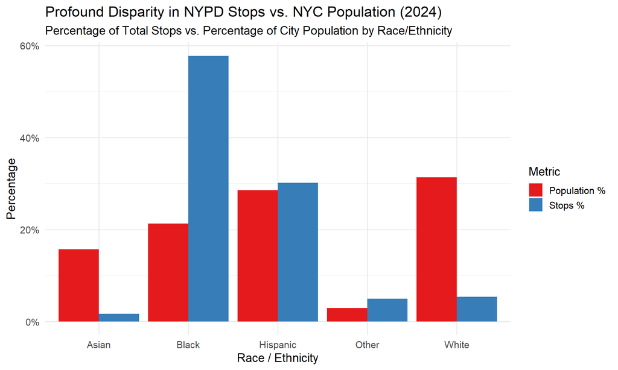

```r
disparity_plot_data <- disparity_data %>%
  select(Race_Group, `Population %` = Pop_Pct, `Stops %` = Stops_Pct) %>%
  pivot_longer(cols = c("Population %", "Stops %"),
               names_to = "Metric",
               values_to = "Percentage")

ggplot(disparity_plot_data, aes(x = Race_Group, y = Percentage, fill = Metric)) +
  geom_col(position = "dodge") +
  scale_y_continuous(labels = scales::percent_format()) +
  labs(
    title = "Profound Disparity in NYPD Stops vs. NYC Population (2024)",
    subtitle = "Percentage of Total Stops vs. Percentage of City Population by Race/Ethnicity",
    x = "Race / Ethnicity",
    y = "Percentage",
    fill = "Metric"
  ) +
  theme_minimal(base_size = 14) +
  scale_fill_brewer(palette = "Set1")
```

## 3.3. Statistical Test: Chi-Squared Goodness-of-Fit

To see if this difference is statistically significant, I’ll use a Chi-Squared Goodness-of-Fit test. This test compares the stop counts I observed for each race against the counts I’d expect to see based on the city’s population.

- **Null Hypothesis (**$H_0$): The number of police stops for each racial/ethnic group is proportional to that group’s share of the NYC population.
- **Alternative Hypothesis (**$H_A$): The number of police stops is *not* proportional to the population distribution.

```r
chi_sq_test_race <- chisq.test(x = disparity_data$Observed_Stops,
                               p = disparity_data$Pop_Pct)

print(chi_sq_test_race)
```

```
##
##  Chi-squared test for given probabilities
##
## data:  disparity_data$Observed_Stops
## X-squared = 24752, df = 4, p-value < 2.2e-16
```

**Conclusion:** The **p-value is effectively zero** (`< 2.2e-16`). This means I can overwhelmingly reject the null hypothesis. There is conclusive statistical evidence that the distribution of police stops across racial and ethnic groups is not proportional to their representation in the NYC population.

# 4. Geospatial Analysis: Where Do Stops Occur?

Having established *who* is stopped, I’ll now analyze *where*. This section maps stop locations and compares stop frequencies across boroughs to their respective populations.

## 4.1. Mapping Stop Concentrations

First, I’ll filter for stops with valid coordinates and project them onto a map of NYC’s five boroughs.

```r
nyc_counties_raw <- counties(state = "36", cb = TRUE, progress_bar = FALSE) %>%
  filter(COUNTYFP %in% c("005", "047", "061", "081", "085")) %>%
  st_transform(crs = 4326)

stops_sf <- police_stops %>%
  mutate(
    STOP_LOCATION_X = as.numeric(STOP_LOCATION_X),
    STOP_LOCATION_Y = as.numeric(STOP_LOCATION_Y)
  ) %>%
  filter(
    !is.na(STOP_LOCATION_X) & !is.na(STOP_LOCATION_Y) &
    STOP_LOCATION_X != 0 & STOP_LOCATION_Y != 0
  ) %>%
  st_as_sf(coords = c("STOP_LOCATION_X", "STOP_LOCATION_Y"), crs = 2263) %>%
  st_transform(crs = st_crs(nyc_counties_raw))

stops_within_nyc <- st_intersection(stops_sf, st_union(nyc_counties_raw))
```

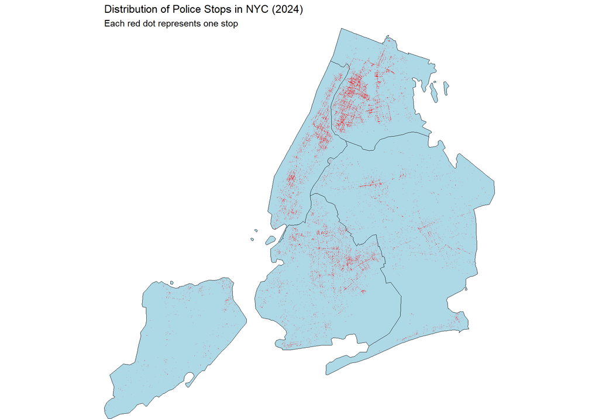

```r
ggplot() +
  geom_sf(data = nyc_counties_raw, fill = "lightblue", color = "black") +
  geom_sf(data = stops_within_nyc, size = 0.1, alpha = 0.1, color = "red") +
  coord_sf(
    xlim = st_bbox(nyc_counties_raw)[c("xmin", "xmax")],
    ylim = st_bbox(nyc_counties_raw)[c("ymin", "ymax")],
    expand = FALSE
  ) +
  labs(title = "Distribution of Police Stops in NYC (2024)",
       subtitle = "Each red dot represents one stop") +
  theme_void()
```

**Observation:** Stops are not evenly distributed. There are heavy concentrations in specific areas of Brooklyn, the Bronx, and Manhattan, with far fewer stops in Queens and Staten Island.

## 4.2. Borough Disparities: Stops vs. Population

Now I’ll aggregate stops by borough and compare these figures to population data, similar to the racial analysis.

```r
pop_table <- tibble(
  Borough = c("The Bronx", "Brooklyn", "Manhattan", "Queens", "Staten Island"),
  Population = c(1379946, 2590516, 1596273, 2278096, 491133)
)

county_to_borough <- tibble(
  NAME = c("Bronx", "Kings", "New York", "Queens", "Richmond"),
  Borough = c("The Bronx", "Brooklyn", "Manhattan", "Queens", "Staten Island")
)

nyc_boroughs_analysis <- left_join(nyc_counties_raw, county_to_borough, by = "NAME")

stops_in_boroughs <- st_join(stops_sf, nyc_boroughs_analysis, join = st_within) %>%
  st_drop_geometry() %>%
  count(Borough) %>%
  rename(Stops = n)

borough_data <- nyc_boroughs_analysis %>%
  left_join(pop_table, by = "Borough") %>%
  left_join(stops_in_boroughs, by = "Borough") %>%
  mutate(
    Stops = replace_na(Stops, 0),
    Pop_Pct = Population / sum(Population) * 100,
    Stops_Pct = Stops / sum(Stops) * 100,
    Stops_Per_1k = (Stops / Population) * 1000
  )
```

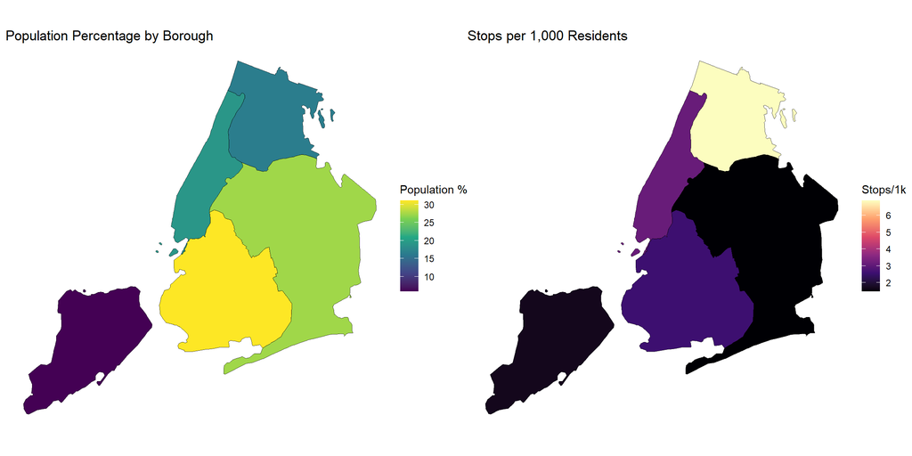

```r
pop_map <- ggplot(borough_data) +
  geom_sf(aes(fill = Pop_Pct)) +
  scale_fill_viridis_c(name = "Population %") +
  labs(title = "Population Percentage by Borough") +
  theme_void()

stops_map <- ggplot(borough_data) +
  geom_sf(aes(fill = Stops_Per_1k)) +
  scale_fill_viridis_c(name = "Stops/1k", option = "magma") +
  labs(title = "Stops per 1,000 Residents") +
  theme_void()

pop_map + stops_map
```

## 4.3. Statistical Test: Chi-Squared Goodness-of-Fit (Boroughs)

I’ll formalize this with another Chi-Squared test. This will tell me if the number of stops in each borough is proportional to its population.

- **Null Hypothesis (**$H_0$): The number of police stops in each borough is proportional to its population.
- **Alternative Hypothesis (**$H_A$): The number of police stops in each borough is not proportional to its population.

```r
chi_sq_test_borough <- chisq.test(x = borough_data$Stops,
                                  p = borough_data$Pop_Pct / 100)

print(chi_sq_test_borough)
```

```
##
##  Chi-squared test for given probabilities
##
## data:  borough_data$Stops
## X-squared = 9015.6, df = 4, p-value < 2.2e-16
```

**Conclusion:** As with the racial analysis, the **p-value is effectively zero**. I can reject the null hypothesis. There is strong statistical evidence that the geographic distribution of police stops across NYC boroughs is not proportional to their populations.

# 5. Temporal Analysis: When Do Stops Occur?

This section explores the daily and monthly patterns of stops. To analyze stops relative to “Day” vs. “Night,” I need to define those periods. Web scraping sunrise/sunset times can be unreliable, so I’ll use a more robust method: defining “Night” as the hours before 7 AM or after 8 PM (20:00).

## 5.1. Visualizing Stops: Day vs. Night

Now I can classify each stop as “Day” or “Night” and visualize the hourly distribution.

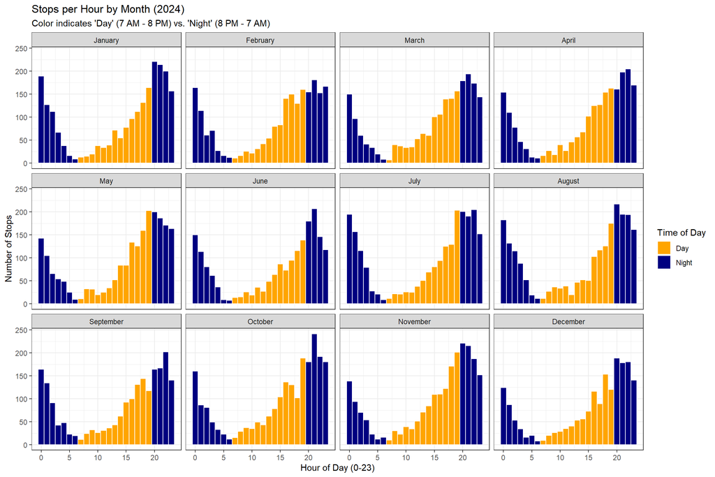

```r
stops_with_time <- police_stops %>%
  filter(!is.na(Hour)) %>%
  mutate(
    Time_of_Day = ifelse(Hour < 7 | Hour >= 20, "Night", "Day")
  )

ggplot(stops_with_time, aes(x = Hour, fill = Time_of_Day)) +
  geom_histogram(binwidth = 1, color = "white") +
  facet_wrap(~ MONTH, scales = "fixed") +
  scale_fill_manual(values = c("Day" = "orange", "Night" = "navy"), name = "Time of Day") +
  labs(
    title = "Stops per Hour by Month (2024)",
    subtitle = "Color indicates 'Day' (7 AM - 8 PM) vs. 'Night' (8 PM - 7 AM)",
    x = "Hour of Day (0-23)",
    y = "Number of Stops"
  ) +
  theme_bw()
```

## 5.2. Statistical Test: Paired t-test

To confirm this, I’ll use a **paired t-test**. The data is “paired” because I’m comparing the day and night counts for the *same calendar day*, which helps control for other factors like weather or city events.

```r
paired_data <- stops_with_time %>%
  group_by(Date, Time_of_Day) %>%
  summarise(count = n(), .groups = 'drop') %>%
  pivot_wider(names_from = Time_of_Day, values_from = count, values_fill = 0)

t_test_result <- t.test(paired_data$Night, paired_data$Day, paired = TRUE)

print(t_test_result)
```

```
##
##  Paired t-test
##
## data:  paired_data$Night and paired_data$Day
## t = 12.064, df = 365, p-value < 2.2e-16
## alternative hypothesis: true mean difference is not equal to 0
## 95 percent confidence interval:
##   7.807426 10.848311
## sample estimates:
## mean difference
##        9.327869
```

# 6. Text Analysis: How Are Suspects Described?

This section delves into the free-text `SUSPECT_OTHER_DESCRIPTION` column to identify common terms and seasonal trends.

## 6.1. Top 10 Most Common Words

I’ll tokenize the text, convert it to lowercase, remove common English “stop words” (like ‘the’, ‘is’, ‘a’), and filter out non-descriptive placeholders like “null” to isolate meaningful keywords.

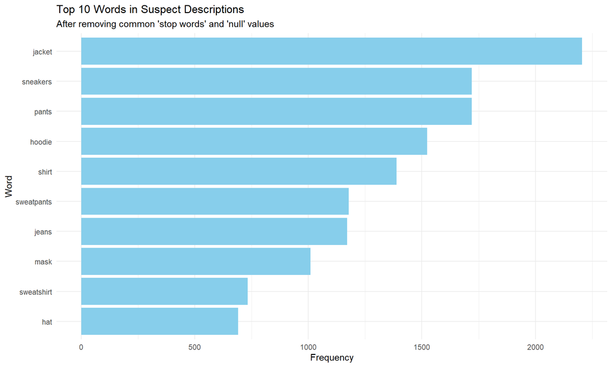

```r
word_counts <- police_stops %>%
  filter(!is.na(SUSPECT_OTHER_DESCRIPTION)) %>%
  unnest_tokens(word, SUSPECT_OTHER_DESCRIPTION) %>%
  anti_join(get_stopwords(), by = "word") %>%
  filter(!word %in% c("null", "black", "white", "blue", "red", "green",
                      "yellow", "orange", "purple", "gray", "grey", "brown", "wearing")) %>%
  count(word, sort = TRUE)

top_10_words <- head(word_counts, 10)

ggplot(top_10_words, aes(x = reorder(word, n), y = n)) +
  geom_col(fill = "skyblue") +
  coord_flip() +
  labs(title = "Top 10 Words in Suspect Descriptions",
       subtitle = "After removing common 'stop words' and 'null' values",
       x = "Word", y = "Frequency") +
  theme_minimal()
```

## 6.2. Seasonal Trends in Descriptions

Are certain descriptions more common in different seasons? I’ll analyze word frequencies on a monthly basis to find out.

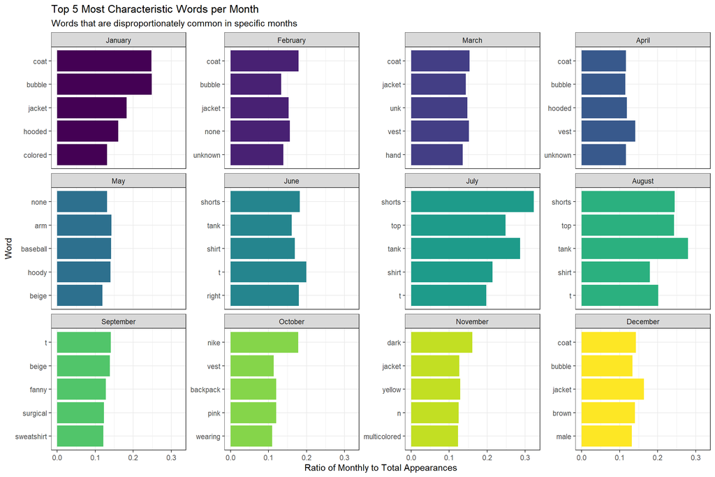

```r
monthly_word_ratios <- police_stops %>%
  filter(!is.na(SUSPECT_OTHER_DESCRIPTION)) %>%
  unnest_tokens(word, SUSPECT_OTHER_DESCRIPTION) %>%
  anti_join(get_stopwords(), by = "word") %>%
  count(MONTH, word) %>%
  group_by(word) %>%
  mutate(total_n = sum(n)) %>%
  ungroup() %>%
  filter(total_n >= 100) %>%
  mutate(ratio = n / total_n)

top_monthly_words <- monthly_word_ratios %>%
  group_by(MONTH) %>%
  slice_max(order_by = ratio, n = 5)

ggplot(top_monthly_words, aes(x = reorder(word, ratio), y = ratio, fill = MONTH)) +
  geom_col(show.legend = FALSE) +
  coord_flip() +
  facet_wrap(~ MONTH, scales = "free_y") +
  labs(title = "Top 5 Most Characteristic Words per Month",
       subtitle = "Words that are disproportionately common in specific months",
       x = "Word", y = "Ratio of Monthly to Total Appearances") +
  theme_bw()
```

## 7. Analysis of Stop Outcomes

Finally, I’ll analyze the **outcome** of the stops. While the previous sections established that Black and Hispanic individuals are stopped disproportionately often, this section asks: *once stopped, what happens?*

A critical measure here is the **Arrest Rate** (sometimes called the “Hit Rate”). This measures the percentage of stops that result in an actual arrest.

### 7.1. Arrest Rates by Race/Ethnicity

I’ll calculate the arrest rate for each racial group.

```r
outcome_data <- police_stops %>%
  filter(!is.na(SUSPECT_RACE_DESCRIPTION)) %>%
  mutate(Race_Group = case_when(
    SUSPECT_RACE_DESCRIPTION == "BLACK" ~ "Black",
    SUSPECT_RACE_DESCRIPTION == "WHITE" ~ "White",
    SUSPECT_RACE_DESCRIPTION == "ASIAN / PACIFIC ISLANDER" ~ "Asian",
    SUSPECT_RACE_DESCRIPTION == "WHITE HISPANIC" ~ "Hispanic",
    SUSPECT_RACE_DESCRIPTION == "BLACK HISPANIC" ~ "Hispanic",
    TRUE ~ "Other"
  ),
  Arrested_Logical = (SUSPECT_ARRESTED_FLAG == "Y")
  ) %>%
  group_by(Race_Group) %>%
  summarise(
    Total_Stops = n(),
    Arrest_Rate = mean(Arrested_Logical, na.rm = TRUE)
  ) %>%
  filter(Race_Group != "Other")

kable(outcome_data,
      caption = "Arrest Rate ('Hit Rate') by Race/Ethnicity",
      digits = c(0, 0, 3))
```

Arrest Rate (‘Hit Rate’) by Race/Ethnicity

| Race_Group | Total_Stops | Arrest_Rate |
| --- | --- | --- |
| Asian | 435 | 0.395 |
| Black | 14662 | 0.270 |
| Hispanic | 7662 | 0.276 |
| White | 1367 | 0.388 |

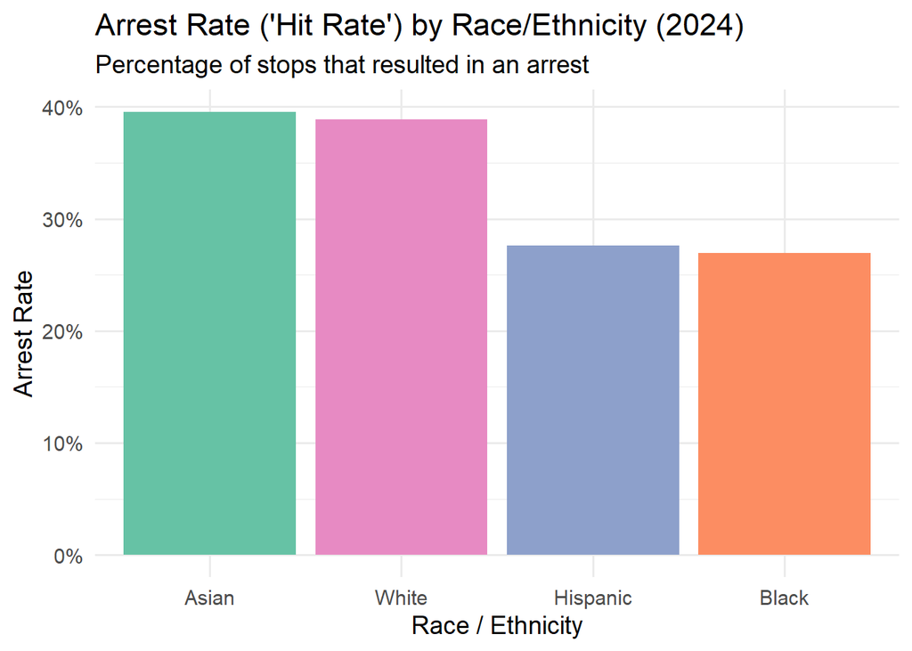

```r
ggplot(outcome_data, aes(x = reorder(Race_Group, -Arrest_Rate), y = Arrest_Rate, fill = Race_Group)) +   geom_col(show.legend = FALSE) +   scale_y_continuous(labels = scales::percent_format()) +   labs(     title = "Arrest Rate ('Hit Rate') by Race/Ethnicity (2024)",     subtitle = "Percentage of stops that resulted in an arrest",     x = "Race / Ethnicity",     y = "Arrest Rate"   ) +   theme_minimal(base_size = 14) +   scale_fill_brewer(palette = "Set2")
```

### 7.3. Interpretation: The “Hit Rate” Hypothesis

In criminology and economics, this phenomenon is often analyzed using the **“Outcome Test”** (proposed by Nobel laureate Gary Becker). This disparity suggests a difference in the **“threshold of suspicion”**:

1. **High Hit Rate (White/Asian):** The higher arrest rate for White and Asian suspects suggests that officers generally only stop these individuals when there is clear, obvious evidence of criminal activity (a high threshold).
2. **Low Hit Rate (Black/Hispanic):** The lower arrest rate for Black and Hispanic suspects suggests a lower threshold for stopping these individuals. A lower “hit rate” implies that more innocent people within these groups are being stopped, questioned, and released without charge.

**Conclusion:** The data suggests that while minority groups face a much higher volume of stops, the *yield* (arrests) from those stops is significantly lower, indicating that the standard of evidence required to initiate a stop may be applied unevenly across racial groups.

# 8. Summary, Limitations, and Conclusion

## 8.1. Key Insights

This analysis of the 2024 NYPD Stop-and-Frisk data revealed several critical, statistically significant patterns:

This project demonstrates analytical skills, but it is not a comprehensive sociological study. Key limitations include:

- **Reporting Bias:** The data is based on what officers report. We cannot analyze stops that were not recorded.
- **Missing Variables:** We lack crucial context, such as the initial reason for the stop, neighborhood-level crime rates, or whether contraband was found. This limits our ability to explain *why* these disparities exist.
- **Correlation vs. Causation:** This analysis is **descriptive and correlational, not causal**. I have identified *what* is happening, but cannot definitively prove *why* (e.g., I cannot prove that race is the *cause* of the higher arrest rate, only that they are correlated).

## 8.3. Conclusion

The findings paint a clear picture: in 2024, the Stop-and-Frisk policy was not applied uniformly. The data shows significant, statistically-backed disparities by **race**, **borough**, and **time of day**. This analysis serves as a clear example of how data science can be used to quantify and bring clarity to important, ongoing social issues.